# Coding Assignment 1

Group 15

Due: 2023-10-01 23:59

```r
# Put any packages you want here
library(gt)
library(tidyverse)
```

```r
library(gtsummary)
library(plotly)
library(readxl)
library(plotly)
library(corrplot)
```

A Florida health insurance company wants to predict annual claims for individual clients. The company pulls a random sample of 100 customers. The owner wishes to charge an actuarially fair premium to ensure a normal rate of return. The owner collects all of their current customer’s health care expenses from the last year and compares them with what is known about each customer’s plan.

The data on the 100 customers in the sample is as follows:

- Charges: Total medical expenses for a particular insurance plan (in dollars)
- Age: Age of the primary beneficiary
- BMI: Primary beneficiary’s body mass index (kg/m2)
- Female: Primary beneficiary’s birth sex (0 = Male, 1 = Female)
- Children: Number of children covered by health insurance plan (includes other dependents as well)
- Smoker: Indicator if primary beneficiary is a smoker (0 = non-smoker, 1 = smoker)
- Cities: Dummy variables for each city with the default being Sanford

Answer the following questions using complete sentences and attach all output, plots, etc. within this report.

**For this assignment, ignore the categorical variables (gender, smoker, cities)**

## Question 1

Perform univariate analyses on the quantitative variables (center, shape, spread). Include descriptive statistics, and histograms. Be sure to use terms discussed in class such as bimodal, skewed left, etc.

## Center

This will contain the mean, median and mode.

```r
mean(Insurance_Data_Group15$Charges)
```

```
## [1] 12380.81
```

```r
mean(Insurance_Data_Group15$Age)
```

```
## [1] 39.28
```

```r
mean(Insurance_Data_Group15$BMI)
```

```
## [1] 30.02625
```

```r
mean(Insurance_Data_Group15$Children)
```

```
## [1] 1.2
```

```r
median(Insurance_Data_Group15$Charges)
```

```
## [1] 8680.385
```

```r
median(Insurance_Data_Group15$Age)
```

```
## [1] 38.5
```

```r
median(Insurance_Data_Group15$BMI)
```

```
## [1] 30.4275
```

```r
median(Insurance_Data_Group15$Children)
```

```
## [1] 1
```

```r
getModes <- function(x) {
  ux <- unique(x)
  tab <- tabulate(match(x, ux))
  ux[tab == max(tab)]
}
getModes(Insurance_Data_Group15$Charges)
```

```
##   [1] 15019.760  2585.269  1984.453  6184.299  5584.306  8017.061  1832.094
##   [8]  6986.697 15006.579 40720.551 13047.332 24671.663  7281.506 11554.224
##  [15]  1748.774  2200.831  3757.845  7740.337 14001.134 42112.236 13429.035
##  [22]  9778.347  6289.755 10928.849 18310.742 36219.405 10982.501 11512.405
##  [29]  1534.304  6067.127  5425.023  4076.497  8965.796  3766.884  5757.413
##  [36] 11729.680  1877.929  4766.022 14210.536  7323.735  9625.920  5693.431
##  [43]  8606.217  4438.263  3861.210 10072.055 48517.563 15612.193  4894.753
##  [50]  8733.229  9447.382 12592.534 25678.778  3756.622 28287.898  6117.494
##  [57]  1969.614 41034.221 20781.489  4795.657  7639.417 11534.873 29330.983
##  [64]  5354.075 44641.197 12890.058  8068.185 24915.221 14449.854 11538.421
##  [71]  1875.344  2755.021  4667.608  9724.530  5934.380 19594.810 34806.468
##  [78] 12363.547 11150.780 13616.359  1909.527 12323.936 13415.038  4751.070
##  [85]  8605.362  2480.979  5373.364  4134.082 22493.660  3925.758  7448.404
##  [92] 13844.506 62592.873  8627.541 19107.780 11884.049  5031.270  4402.233
##  [99] 37270.151  2103.080
```

```r
getModes(Insurance_Data_Group15$Age)
```

```
## [1] 21 19 31
```

```r
getModes(Insurance_Data_Group15$BMI)
```

```
## [1] 30.495
```

```r
getModes(Insurance_Data_Group15$Children)
```

```
## [1] 0
```

## Shape

For this, I am going to create a histogram on the variables

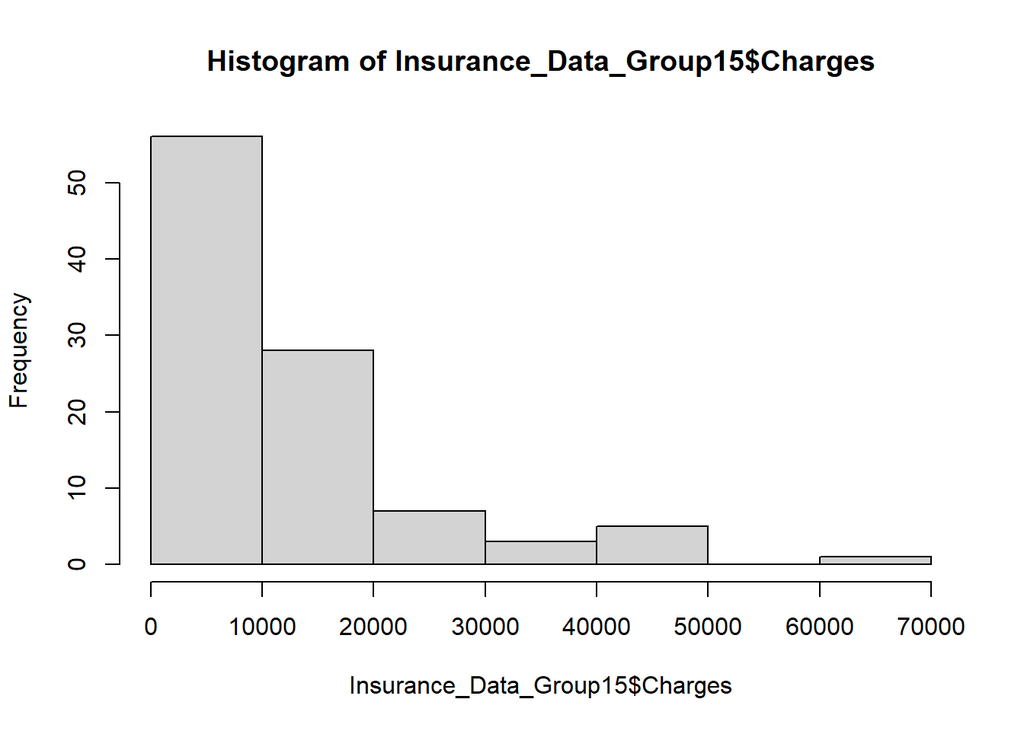

```r
hist(Insurance_Data_Group15$Charges)
```

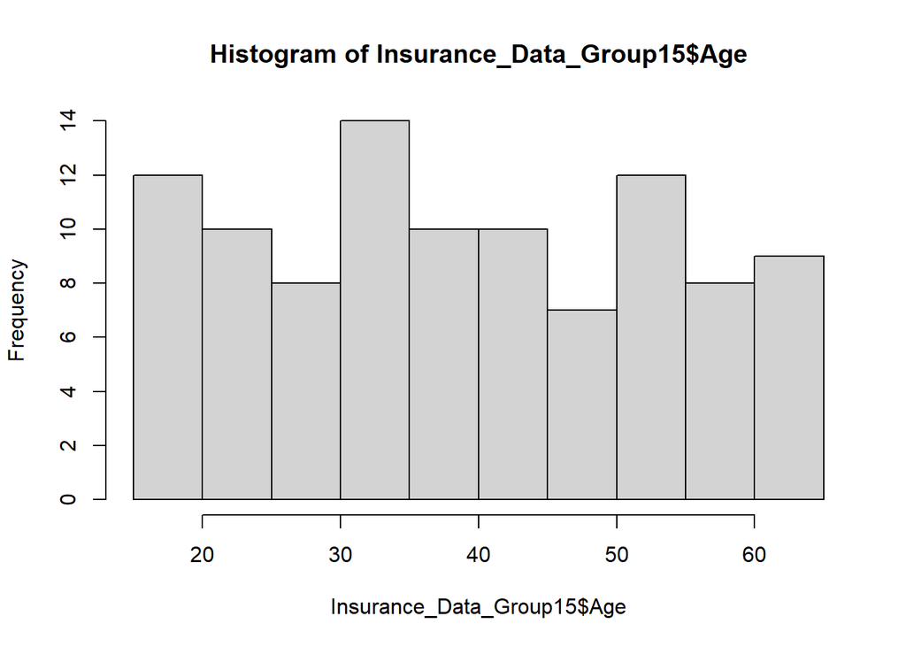

```r
hist(Insurance_Data_Group15$Age)
```

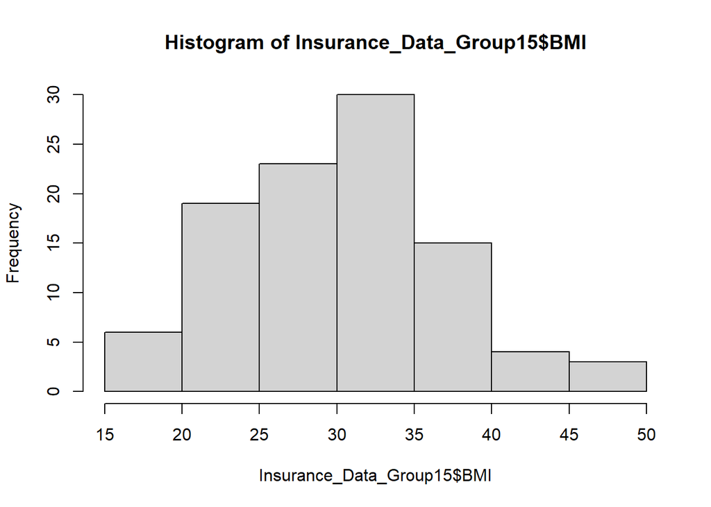

```r
hist(Insurance_Data_Group15$BMI)
```

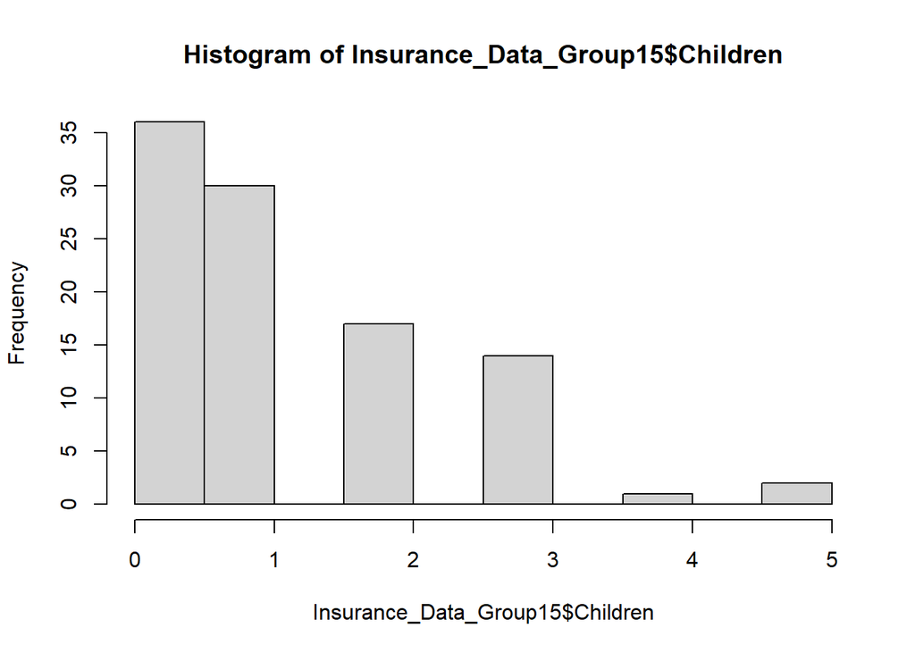

```r
hist(Insurance_Data_Group15$Children)
```

## Spread and Visualization

Standard deviation, high,low, range

```r
var(Insurance_Data_Group15$Charges, na.rm = TRUE)
```

```
## [1] 137106467
```

```r
sd(Insurance_Data_Group15$Charges, na.rm = TRUE)
```

```
## [1] 11709.25
```

```r
IQR(Insurance_Data_Group15$Charges, na.rm = TRUE)
```

```
## [1] 9095.415
```

```r
range(Insurance_Data_Group15$Charges, na.rm = TRUE)
```

```
## [1]  1534.304 62592.873
```

```r
var(Insurance_Data_Group15$Age, na.rm = TRUE)
```

```
## [1] 203.4562
```

```r
sd(Insurance_Data_Group15$Age, na.rm = TRUE)
```

```
## [1] 14.26381
```

```r
IQR(Insurance_Data_Group15$Age, na.rm = TRUE)
```

```
## [1] 25.25
```

```r
range(Insurance_Data_Group15$Age, na.rm = TRUE)
```

```
## [1] 18 64
```

```r
var(Insurance_Data_Group15$BMI, na.rm = TRUE)
```

```
## [1] 45.90943
```

```r
sd(Insurance_Data_Group15$BMI, na.rm = TRUE)
```

```
## [1] 6.77565
```

```r
IQR(Insurance_Data_Group15$BMI, na.rm = TRUE)
```

```
## [1] 9.26875
```

```r
range(Insurance_Data_Group15$BMI, na.rm = TRUE)
```

```
## [1] 17.40 46.75
```

```r
var(Insurance_Data_Group15$Children, na.rm = TRUE)
```

```
## [1] 1.474747
```

```r
sd(Insurance_Data_Group15$Children, na.rm = TRUE)
```

```
## [1] 1.214392
```

```r
IQR(Insurance_Data_Group15$Children, na.rm = TRUE)
```

```
## [1] 2
```

```r
range(Insurance_Data_Group15$Children, na.rm = TRUE)
```

```
## [1] 0 5
```

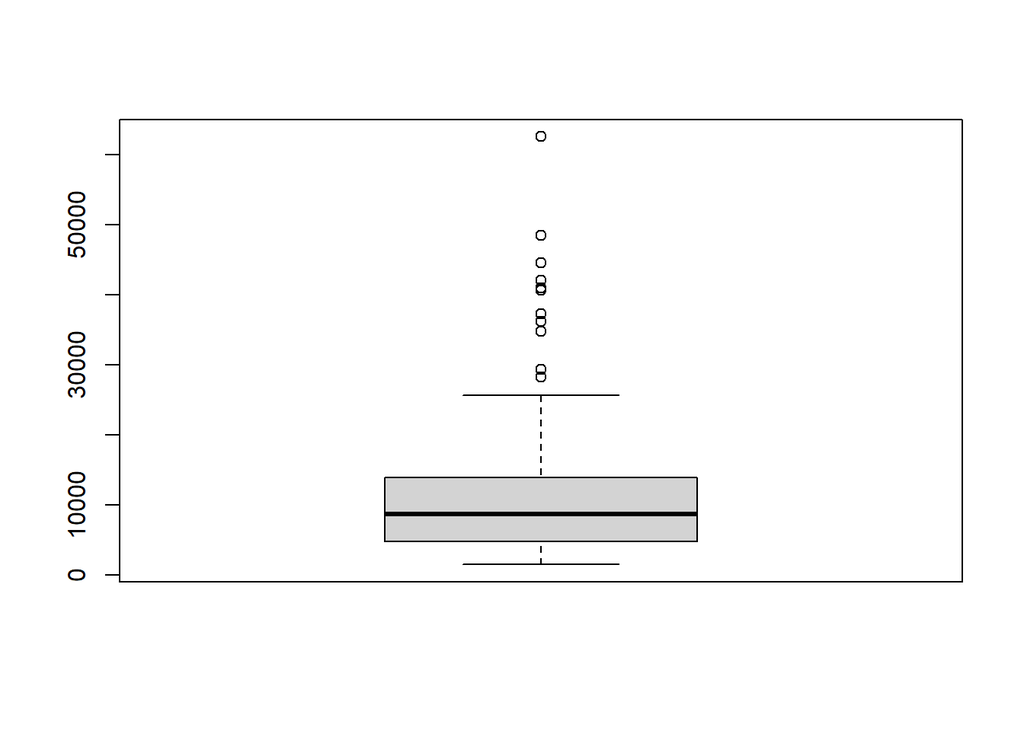

```r
boxplot(Insurance_Data_Group15$Charges)
```

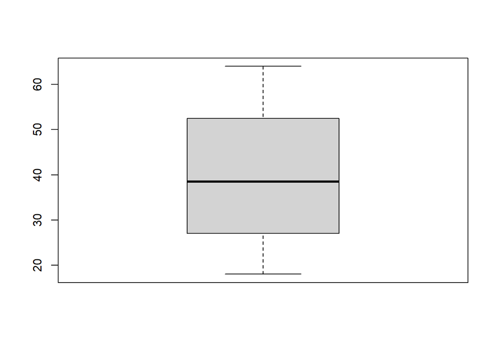

```r
boxplot(Insurance_Data_Group15$Age)
```

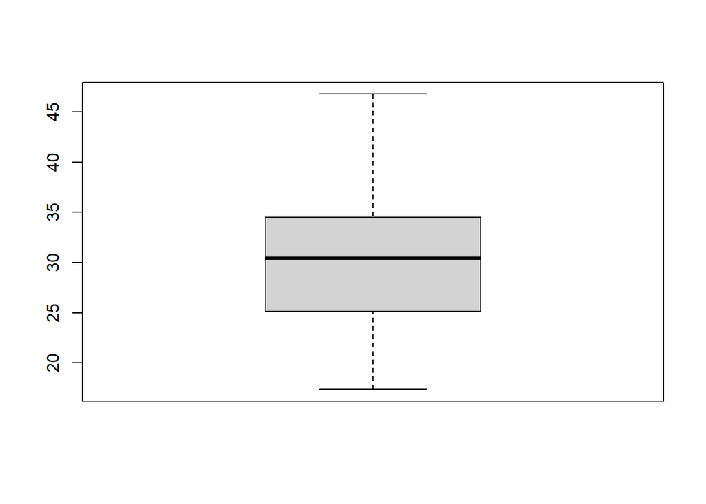

```r
boxplot(Insurance_Data_Group15$BMI)
```

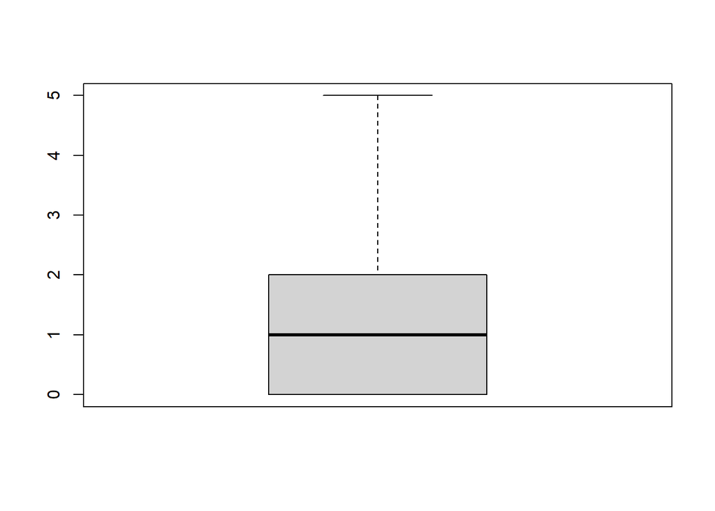

```r
boxplot(Insurance_Data_Group15$Children)
```

## Summary

Charges:

Mean $12380.81

Median $8680.39

Mode no mode for data

The data for total medical expenses based on insurance plan for the sample of 100 customers is skewed to the right as seen in the histogram, this is due to the fact that the mean ($12381) is greater than the median ($8680). Another factor in the skewness of the data for charges are the outliers on the higher end of the data that lie past the middle 50% of responses. Based on the boxplot we can see how many outliers affect the data in the upper 25% of data. The data has no mode

Age:

Mean 39 years

Median 38.5 years

Mode 21, 19, 31

There is a wide range of responses to the age of the primary beneficiary that goes from just 18 years old to 64 years old. The actual distribution of the data shows a fairly uniform distribution with no clear outliers affecting skewness or shape. There is an almost even number of responses for each age listed. The boxplot created further shows the even spread of ages and that each quartile is roughly the same size. The data for ages is multimodal with the ages 19,21, and 31 showing up the most.

BMI:

Mean 30.03

Median 30.43

Mode 30.5

The data for BMI of the primary beneficiaries is normally distributed with a very slight skewness to the right. The mean and median are almost the same which tells us that the shape of the data will most likely be a normal bell curve. There are no outliers from this data set and based on the boxplot we can further see the normal distribution of data. The data is unimodal with the BMI of 30.5 showing up the most.

Children /Dependents Covered:

Mean 1.2

Median 1

Mode 0

## Question 2

Perform bivariate analyses on the quantitative variables (direction, strength and form). Describe the linear association between all variables.

Outliers and Correlation

## Direction and Strength

Range is [-1, 1] Closer to -1, the stronger the negative linear relationship Closer to 1, the stronger the positive linear relationship Closer to 0, the weaker the linear relationship

```r
cor(Insurance_Data_Group15$Charges,Insurance_Data_Group15$Age)
```

```
## [1] 0.3025877
```

```r
cor(Insurance_Data_Group15$Charges,Insurance_Data_Group15$BMI)
```

```
## [1] 0.1349604
```

```r
cor(Insurance_Data_Group15$Charges,Insurance_Data_Group15$Children)
```

```
## [1] 0.03954699
```

```r
cor(Insurance_Data_Group15$Age,Insurance_Data_Group15$BMI)
```

```
## [1] 0.0401536
```

```r
cor(Insurance_Data_Group15$Age,Insurance_Data_Group15$Children)
```

```
## [1] 0.08070615
```

```r
cor(Insurance_Data_Group15$BMI,Insurance_Data_Group15$Children)
```

```
## [1] -0.01254602
```

## Form

Visualize this relationship with a scatterplot

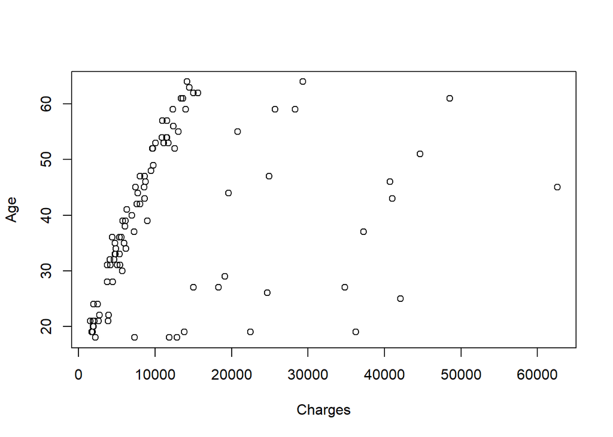

```r
plot(Insurance_Data_Group15$Charges,Insurance_Data_Group15$Age,
     xlab = "Charges",
     ylab = "Age")
```

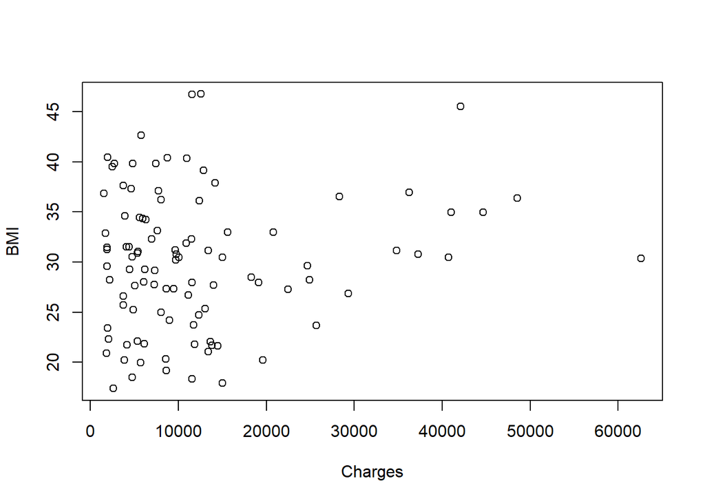

```r
plot(Insurance_Data_Group15$Charges,Insurance_Data_Group15$BMI,
     xlab = "Charges",
     ylab = "BMI")
```

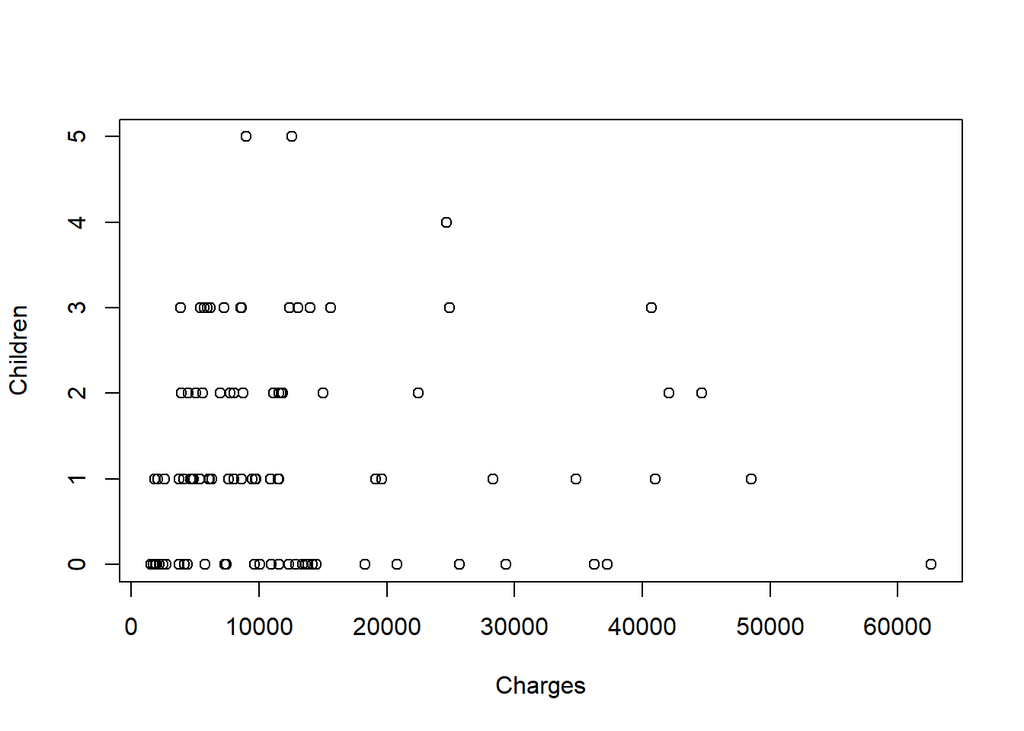

```r
plot(Insurance_Data_Group15$Charges,Insurance_Data_Group15$Children,
     xlab = "Charges",
     ylab = "Children")
```

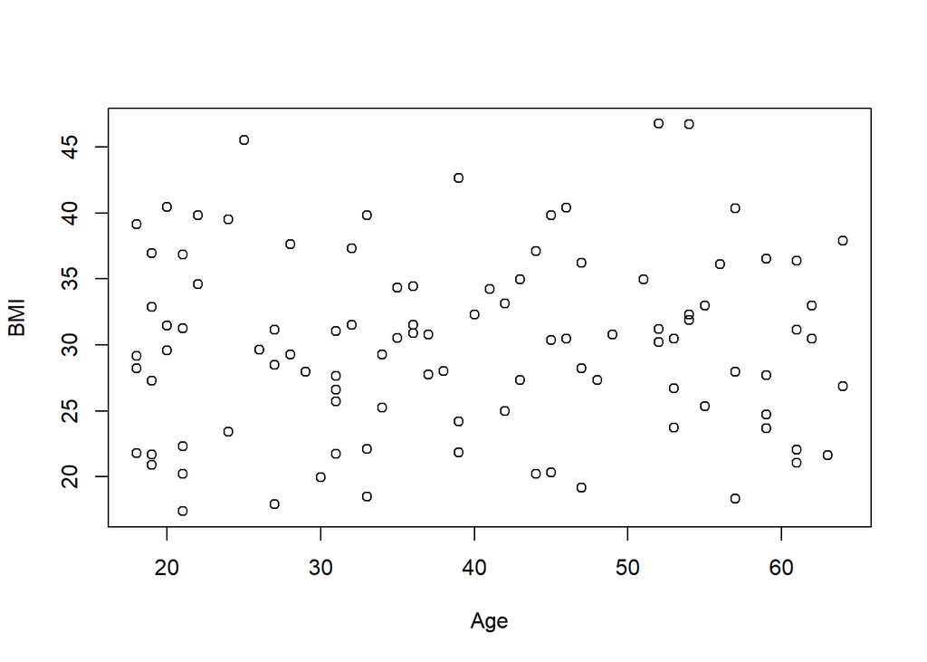

```r
plot(Insurance_Data_Group15$Age,Insurance_Data_Group15$BMI,
     xlab = "Age",
     ylab = "BMI")
```

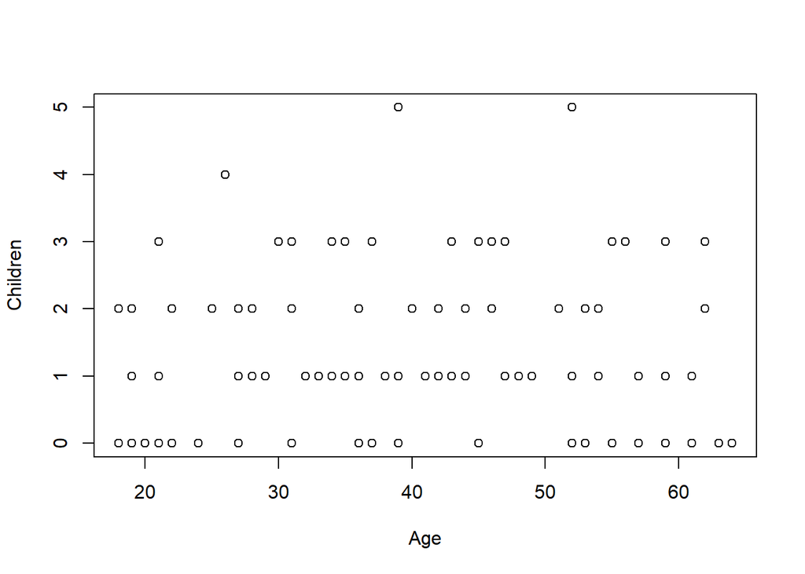

```r
plot(Insurance_Data_Group15$Age,Insurance_Data_Group15$Children,
     xlab = "Age",
     ylab = "Children")
```

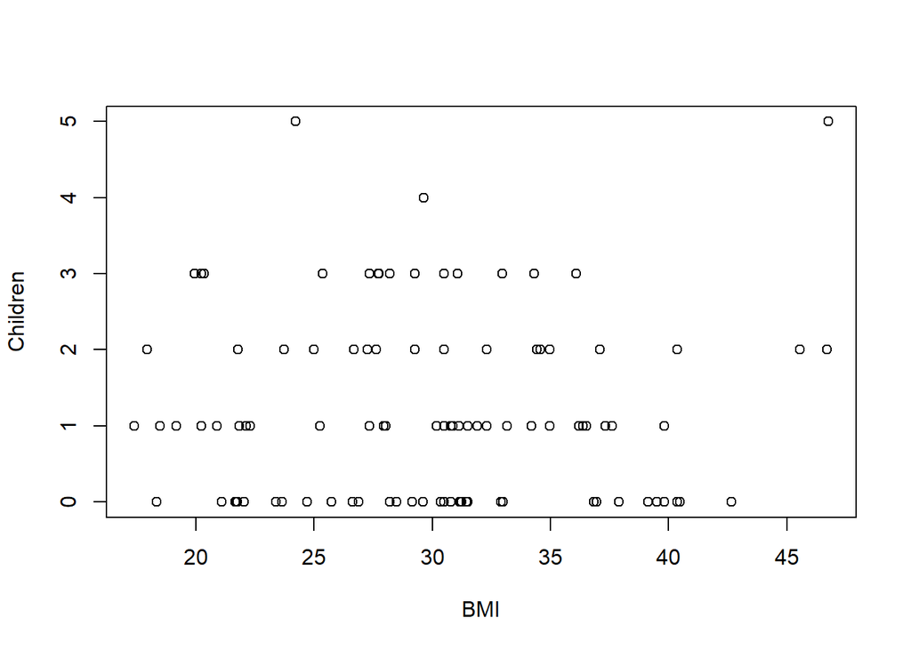

```r
plot(Insurance_Data_Group15$BMI,Insurance_Data_Group15$Children,
     xlab = "BMI",
     ylab = "Children")
```

## Summary

(Charges vs Children) Here, this linear scatterplot compares medical expenses (Charges) to the number of children covered by the insurance plan. The points are dispersed across the plot without forming any recognizable pattern. The correlation between Charges and Children is approximately 0.04, indicating a very weak positive relationship.

(Age vs BMI) This linear scatter plot represents the relationship between the age of individuals and their Body Mass Index (BMI). The points are scattered with no apparent pattern. Age and BMI have a correlation of about 0.04, suggesting a weak positive relationship.

(Age vs Children) This linear scatterplot shows the age of individuals in relation to the number of children covered. The points exhibit a slightly more defined pattern than the previous plots, although they are still somewhat scattered. Age and Children have a correlation of about 0.08, indicating a slightly stronger,but still weak, positive relationship.

(BMI vs Children) This linear scatterplot compares the Body Mass Index (BMI) with the number of children covered by the insurance plan. The points are scattered across the plot with no clear trend. BMI and Children have a correlation of approximately -0.01, indicating a very weak negative relationship.

## Question 3

Generate a regression equation in the following form:

Charges = B0 + B1 * Age + B2 * BMI + B3 * Children

An eager insurance representative comes back with a potential client. The client is 40, their BMI is 30, and they have one dependent. Using the regression equation above, predict the amount of medical expenses associated with this policy. (Provide a 95% confidence interval as well)

```r
model <- lm(Insurance_Data_Group15$Charges ~ Insurance_Data_Group15$Age + Insurance_Data_Group15$BMI + Insurance_Data_Group15$Children, data = Insurance_Data_Group15)

summary(model)
```

```
##
## Call:
## lm(formula = Insurance_Data_Group15$Charges ~ Insurance_Data_Group15$Age +
##     Insurance_Data_Group15$BMI + Insurance_Data_Group15$Children,
##     data = Insurance_Data_Group15)
##
## Residuals:
##    Min     1Q Median     3Q    Max
##  -9047  -6049  -4415  -2039  48949
##
## Coefficients:
##                                 Estimate Std. Error t value Pr(>|t|)
## (Intercept)                      -3767.6     5973.3  -0.631  0.52970
## Insurance_Data_Group15$Age         243.2       79.5   3.059  0.00288 **
## Insurance_Data_Group15$BMI         213.1      166.8   1.277  0.20468
## Insurance_Data_Group15$Children    165.7      933.1   0.178  0.85944
## ---
## Signif. codes:  0 '***' 0.001 '**' 0.01 '*' 0.05 '.' 0.1 ' ' 1
##
## Residual standard error: 11240 on 96 degrees of freedom
## Multiple R-squared:  0.107,  Adjusted R-squared:  0.07905
## F-statistic: 3.833 on 3 and 96 DF,  p-value: 0.01219
```

```r
newPrediction <- data.frame(Age = 40, BMI = 30, Children = 1)

predict(model,
        newdata = newPrediction,
        interval = "confidence",
        level = .95)
```

```
##           fit        lwr      upr
## 1   18138.600 13762.7151 22514.48
## 2    5212.123  -246.5353 10670.78
## 3    9718.193  4180.9551 15255.43
## 4   11231.750  7077.5792 15385.92
## 5   12653.890  9520.0117 15787.77
## 6   12100.840  8935.4553 15266.22
## 7    5471.394   620.3161 10322.47
## 8   13172.879 10388.6865 15957.07
## 9    6955.220  1802.9542 12107.49
## 10  14413.189 10330.5569 18495.82
## 11  15509.012 10667.8454 20350.18
## 12   9532.849  3368.0059 15697.69
## 13  11637.503  7528.2096 15746.80
## 14  16212.606 12505.0636 19920.15
```

[output cut: 86 more lines]